# Functional genomic landscape of acute myeloid leukaemia

Inês Lameira (PG40080), João Lima (PG55701), Romeu Fernandes (PG45861)

2025-04-11

Trabalho desenvolvido no âmbito da unidade curricular de Extração de Conhecimento de Dados Biológicos (2024/2025), referente ao Mestrado em Bioinformática da Escola de Engenharia da Universidade do Minho. O objetivo deste trabalho é desenvolver scripts em R/ Bioconductor para carregar os dados, préprocessá-los e fazer um conjunto de análises relativas aos datasets de leucemia.

## Packages Utilizados

No desenvolvimento deste trabalho foram vários os packages necessários para realizar as análises que posteriormente serão apresentadas:

```r
#instalar os pacotes necessários
#install.packages("ggplot2")
#install.packages("DESeq2")
#BiocManager::install(c("edgeR"),force =TRUE)
#BiocManager::install(c("Glimma"))
#BiocManager::install(c("gplots"))
#BiocManager::install("org.Hs.eg.db")
#BiocManager::install("fgsea")
```

```r
# Carregar os pacotes necessários
library(ggplot2)
library(tidyr)
library(ggplot2)
library(forcats)
library(RColorBrewer)
library(knitr)
library(readr)
library(edgeR)
library(limma)
library(pheatmap)
library(Glimma)
library(gplots)
library(org.Hs.eg.db)
library(BiocManager)
library(dplyr)
library(fgsea)
```

## Enquadramento

A leucemia mieloide aguda (LMA) é uma doença hematológica agressiva, marcada pela multiplicação descontrolada de precursores mieloides imaturos na medula óssea, levando à interrupção da produção normal de sangue. Esta condição atinge principalmente indivíduos de idade avançada, com uma média de diagnóstico superior a 65 anos<sup>1</sup>. Prevê-se que, anualmente, nos Estados Unidos, mais de 20.000 novos casos de LMA sejam identificados, resultando em cerca de 11.000 óbitos anuais<sup>2</sup>.

A LMA é extremamente diversificada em termos genéticos, com mutações somáticas em genes como *NPM1*, *FLT3*, *IDH1*, *IDH2*, *DNMT3A*, entre outros, desempenhando um papel prognóstico e até terapêutico<sup>3,4</sup>. Pesquisas de sequenciamento em grande escala, como as realizadas pelo The Cancer Genome Atlas (TCGA), possibilitaram a categorização da LMA em diversos subgrupos moleculares com perfis de risco e respostas distintas ao tratamento<sup>5</sup>.

Ainda que tenha havido progressos na terapia, como a implementação de terapias direcionadas contra mutações em FLT3<sup>6</sup> e IDH1/IDH2<sup>7,8</sup>, a terapia convencional que envolve quimioterapia intensiva manteve-se praticamente inalterada nas últimas quatro décadas<sup>9,10</sup>. Adicionalmente, mutações no gene TP53 e mudanças epigenéticas associadas, como mutações genéticas em TET2 ou ASXL1, persistem como desafios clínicos devido à sua ligação com resistência ao tratamento<sup>11,12</sup>.

Neste contexto, o projeto **Beat AML** destaca-se como um marco significativo ao combinar dados funcionais e genómicos de um conjunto de 672 amostras tumorais provenientes de 562 pacientes. Estudos de sequenciamento do exoma, sequenciamento de RNA e testes in vivo de sensibilidade a fármacos foram conduzidos, proporcionando uma perspetiva multidimensional da biologia da LMA<sup>13</sup>. As informações deste estudo estão acessíveis ao público no portal Vizome e representam um recurso valioso para a pesquisa de novos biomarcadores, assinaturas moleculares e possíveis alvos terapêuticos.

Este trabalho, inserido na unidade curricular de **Extração de Conhecimento de Dados Biológicos**, visa empregar técnicas estatísticas e de *data mining* nos dados de expressão genética do *cohort* Beat AML, utilizando R e Bioconductor. As avaliações englobam o pré-processamento e a exploração dos dados, a identificação de genes com expressão diferenciada e a utilização de técnicas de aprendizagem automática para antecipar perfis moleculares e respostas terapêuticas.

## Importação dos datasets

```r
# Importação dos datasets
dc_pacientes <- read.table("data_clinical_patient.txt", sep = "\t", header = TRUE)
dc_amostras <- read.table("data_clinical_sample.txt", sep = "\t", header = TRUE, fill = TRUE)
clinical_patient <- read.table("data_clinical_patient.txt",
                               header = TRUE, sep = "\t", stringsAsFactors = FALSE)
RNASeq_rawcounts <- read.table("BeatAML_RNASeq_rawcounts_2018_10_24.csv",
                               header = TRUE, sep = ",", stringsAsFactors = FALSE)
```

# 1. Pacientes

## 1.0. Pré-análise do dataset

```r
# Análise preliminar do dataset com os dados clínicos dos pacientes
dim(dc_pacientes)
head(dc_pacientes)
names(dc_pacientes)
nrow(dc_pacientes)
ncol(dc_pacientes)
class(dc_pacientes)
unlist(lapply(dc_pacientes, class))
sum(is.na.data.frame(dc_pacientes))
na_por_coluna_pacientes <- colSums(is.na(dc_pacientes))
na_por_coluna_pacientes[na_por_coluna_pacientes > 0]
```

## 1.0.1. Tratamento de valores omissos

```r
# Teste de normalidade
teste_normalidade <- shapiro.test(dc_pacientes$AGE_AT_DIAGNOSIS)
teste_normalidade
```

```
##
##  Shapiro-Wilk normality test
##
## data:  dc_pacientes$AGE_AT_DIAGNOSIS
## W = 0.94076, p-value = 4.39e-14
```

O teste de Shapiro permitiu concluir que a idade não segue uma distribuição normal e portanto os valores omissos foram substituídos pelo mediana.

```r
# Substituindo valores omissos pela mediana
mediana_idade <- median(dc_pacientes$AGE_AT_DIAGNOSIS, na.rm = TRUE)
dc_pacientes$AGE_AT_DIAGNOSIS[is.na(dc_pacientes$AGE_AT_DIAGNOSIS)] <- mediana_idade
sum(is.na(dc_pacientes$AGE_AT_DIAGNOSIS))
```

```
## [1] 0
```

## 1.1. Sexo

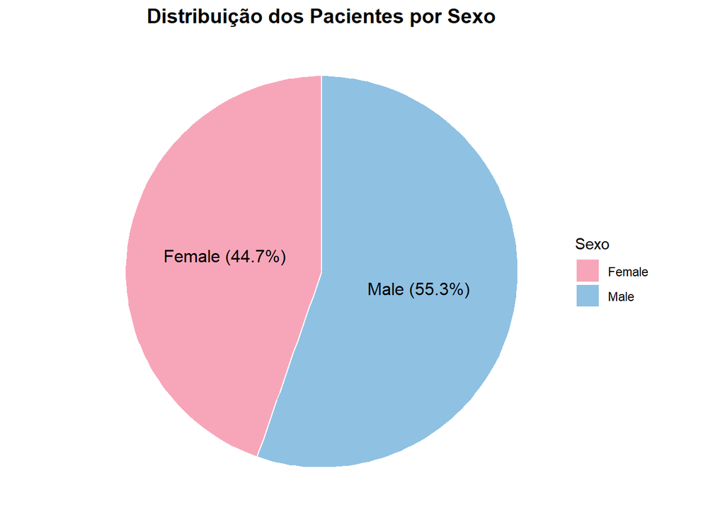

```r
sexo_df <- as.data.frame(table(dc_pacientes$SEX))
colnames(sexo_df) <- c("Sexo", "Contagem")
sexo_df <- sexo_df %>%
  mutate(Percentual = round(Contagem / sum(Contagem) * 100, 1),
         Label = paste0(Sexo, " (", Percentual, "%)"))
cores_sexo <- c("Female" = "#F7A6B9",
                "Male" = "#8FC1E3")

ggplot(sexo_df, aes(x = "", y = Contagem, fill = Sexo)) +
  geom_col(width = 1, color = "white") +
  coord_polar(theta = "y") +
  geom_text(aes(label = Label), position = position_stack(vjust = 0.5), color = "black", size = 4.2) +
  scale_fill_manual(values = cores_sexo) +
  labs(title = "Distribuição dos Pacientes por Sexo", x = NULL, y = NULL, fill = "Sexo") +
  theme_void() +
  theme(plot.title = element_text(hjust = 0.5, face = "bold", size = 14))
```

## 1.2. Etnia

```r
summary(dc_pacientes$ETHNICITY)
```

```
##    Length     Class      Mode
##       562 character character
```

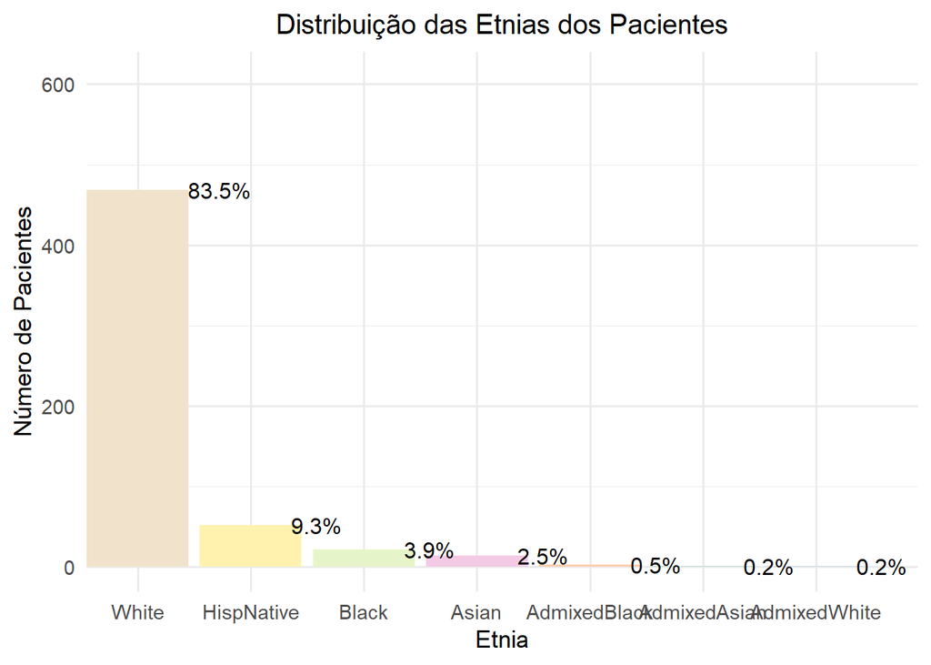

```r
etnia_contagens <- table(dc_pacientes$ETHNICITY)
percentagens_etnia <- round(100 * etnia_contagens / sum(etnia_contagens), 1)

etnia_data <- data.frame(
  Etnia = names(etnia_contagens),
  Contagem = as.numeric(etnia_contagens),
  Percentagem = as.numeric(percentagens_etnia)
)
etnia_data <- etnia_data[order(etnia_data$Contagem), ]

cores_etnia <- brewer.pal(n = max(3, min(nrow(etnia_data), 8)), name = "Pastel2")
ggplot(etnia_data, aes(x = Contagem, y = reorder(Etnia, -Contagem), fill = Etnia)) +
  geom_bar(stat = "identity", show.legend = FALSE) +
  geom_text(aes(label = paste0(Percentagem, "%")),
            hjust = -0.8, size = 4.2, color = "black") +
  scale_fill_manual(values = cores_etnia) +
  scale_y_discrete(expand = expansion(mult = c(0.05, 0.15))) +
  labs(title = "Distribuição das Etnias dos Pacientes",
       x = "Número de Pacientes", y = "Etnia") +
  theme_minimal(base_size = 14) +
  theme(
    axis.text.y = element_text(size = 11),
    axis.text.x = element_text(size = 11),
    axis.title = element_text(size = 13),
    plot.title = element_text(size = 15, hjust = 0.5)
  ) +
  expand_limits(x = max(etnia_data$Contagem) * 1.3) +
  coord_flip()
```

## 1.3. Idade

```r
summary(dc_pacientes$AGE_AT_DIAGNOSIS)
```

```
##    Min. 1st Qu.  Median    Mean 3rd Qu.    Max.
##    1.00   48.00   61.00   57.53   71.00   87.00
```

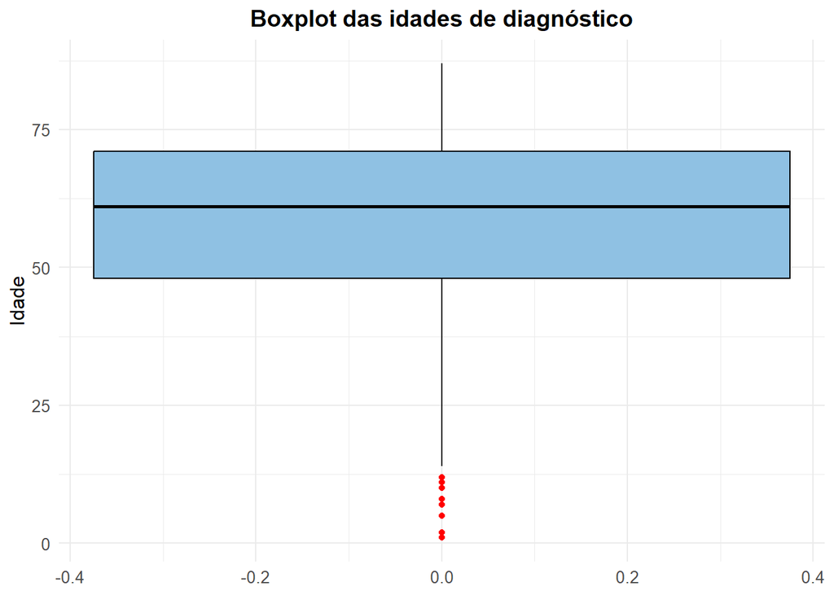

```r
ggplot(dc_pacientes, aes(y = AGE_AT_DIAGNOSIS)) +
  geom_boxplot(fill = "#8FC1E3", color = "black", outlier.color = "red", outlier.shape = 16) +
  labs(title = "Boxplot das idades de diagnóstico",
       y = "Idade", x = NULL) +
  theme_minimal() +
  theme(
    plot.title = element_text(hjust = 0.5, face = "bold", size = 14),
    axis.title.y = element_text(size = 12),
    axis.text = element_text(size = 10)
  )
```

## 1.4. Diagnóstico

```r
summary(dc_pacientes$DIAGNOSIS)
```

```
##    Length     Class      Mode
##       562 character character
```

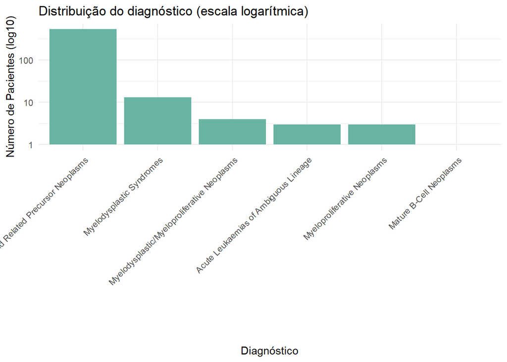

```r
diagnostico_contagens <- table(dc_pacientes$DIAGNOSIS)

diagnostico_contagens <- table(dc_pacientes$DIAGNOSIS)

ggplot(data.frame(Diagnostico = names(diagnostico_contagens), Contagem = as.numeric(diagnostico_contagens)),
       aes(x = reorder(Diagnostico, -Contagem), y = Contagem)) +
  geom_bar(stat = "identity", fill = "#69b3a2") +
  scale_y_log10() +
  labs(title = "Distribuição do diagnóstico (escala logarítmica)",
       x = "Diagnóstico", y = "Número de Pacientes (log10)") +
  theme_minimal() +
  theme(axis.text.x = element_text(angle = 45, hjust = 1))
```

## 1.5. Tratamento

```
##
##
##                                                                                                               29
##                                                                 DLI|Standard Chemotherapy|Bone Marrow Transplant
##                                                                                                                7
##                                      DLI|Standard Chemotherapy|Bone Marrow Transplant|Supportive/Palliative Care
##                                                                                                                3
##                          DLI|Standard Chemotherapy|Bone Marrow Transplant|Targeted Therapy - Kinase Inhibitor(s)
##                                                                                                                1
##              DLI|Standard Chemotherapy|Bone Marrow Transplant|Targeted Therapy - Kinase Inhibitor(s)|Intrathecal
##                                                                                                                1
##                                        DLI|Standard Chemotherapy|Bone Marrow Transplant|Targeted Therapy - Other
##                                                                                                                1
##                                                                                                            Other
##                                                                                                                2
##                                                                                            Standard Chemotherapy
##                                                                                                              258
##                                                                     Standard Chemotherapy|Bone Marrow Transplant
##                                                                                                              105
##                                                         Standard Chemotherapy|Bone Marrow Transplant|Intrathecal
##                                                                                                                6
##                  Standard Chemotherapy|Bone Marrow Transplant|Intrathecal|Targeted Therapy - Kinase Inhibitor(s)
##                                                                                                                2
##                                                               Standard Chemotherapy|Bone Marrow Transplant|Other
##                                                                                                                3
##                                          Standard Chemotherapy|Bone Marrow Transplant|Supportive/Palliative Care
##                                                                                                                4
##                              Standard Chemotherapy|Bone Marrow Transplant|Targeted Therapy - Kinase Inhibitor(s)
##                                                                                                               13
##                                            Standard Chemotherapy|Bone Marrow Transplant|Targeted Therapy - Other
##                                                                                                                8
##     Standard Chemotherapy|Bone Marrow Transplant|Targeted Therapy - Other|Targeted Therapy - Kinase Inhibitor(s)
##                                                                                                                1
##                                                                                Standard Chemotherapy|Intrathecal
##                                                                                                                5
##                                                                          Standard Chemotherapy|Intrathecal|Other
##                                                                                                                1
##                                                                                      Standard Chemotherapy|Other
##                                                                                                                4
##                                                                 Standard Chemotherapy|Supportive/Palliative Care
```

[output cut: 20 more lines]

```
##                                                                                                                1
##                                                             Standard Chemotherapy|Unknown|Bone Marrow Transplant
##                                                                                                                1
##                                                                                       Supportive/Palliative Care
##                                                                                                               11
##                                                                                 Supportive/Palliative Care|Other
##                                                                                                                1
##                                                              Supportive/Palliative Care|Targeted Therapy - Other
##                                                                                                                2
##                                                                           Targeted Therapy - Kinase Inhibitor(s)
##                                                                                                                2
##                                                                                         Targeted Therapy - Other
##                                                                                                                5
##                                                                                                          Unknown
##                                                                                                                4
```

```r
kable(as.data.frame(tratamento_frequencias), col.names = c("Tipo de Tratamento", "Frequência"))
```

| Tipo de Tratamento | Frequência |
| --- | --- |
|  | 29 |
| DLI\|Standard Chemotherapy\|Bone Marrow Transplant | 7 |
| DLI\|Standard Chemotherapy\|Bone Marrow Transplant\|Supportive/Palliative Care | 3 |
| DLI\|Standard Chemotherapy\|Bone Marrow Transplant\|Targeted Therapy - Kinase Inhibitor(s) | 1 |
| DLI\|Standard Chemotherapy\|Bone Marrow Transplant\|Targeted Therapy - Kinase Inhibitor(s)\|Intrathecal | 1 |
| DLI\|Standard Chemotherapy\|Bone Marrow Transplant\|Targeted Therapy - Other | 1 |
| Other | 2 |
| Standard Chemotherapy | 258 |
| Standard Chemotherapy\|Bone Marrow Transplant | 105 |
| Standard Chemotherapy\|Bone Marrow Transplant\|Intrathecal | 6 |
| Standard Chemotherapy\|Bone Marrow Transplant\|Intrathecal\|Targeted Therapy - Kinase Inhibitor(s) | 2 |
| Standard Chemotherapy\|Bone Marrow Transplant\|Other | 3 |
| Standard Chemotherapy\|Bone Marrow Transplant\|Supportive/Palliative Care | 4 |
| Standard Chemotherapy\|Bone Marrow Transplant\|Targeted Therapy - Kinase Inhibitor(s) | 13 |
| Standard Chemotherapy\|Bone Marrow Transplant\|Targeted Therapy - Other | 8 |
| Standard Chemotherapy\|Bone Marrow Transplant\|Targeted Therapy - Other\|Targeted Therapy - Kinase Inhibitor(s) | 1 |
| Standard Chemotherapy\|Intrathecal | 5 |
| Standard Chemotherapy\|Intrathecal\|Other | 1 |
| Standard Chemotherapy\|Other | 4 |
| Standard Chemotherapy\|Supportive/Palliative Care | 20 |
| Standard Chemotherapy\|Supportive/Palliative Care\|Intrathecal | 1 |
| Standard Chemotherapy\|Supportive/Palliative Care\|Targeted Therapy - Kinase Inhibitor(s) | 3 |
| Standard Chemotherapy\|Supportive/Palliative Care\|Targeted Therapy - Kinase Inhibitor(s)\|Targeted Therapy - Other | 1 |
| Standard Chemotherapy\|Supportive/Palliative Care\|Targeted Therapy - Other | 3 |
| Standard Chemotherapy\|Targeted Therapy - Kinase Inhibitor(s) | 24 |
| Standard Chemotherapy\|Targeted Therapy - Kinase Inhibitor(s)\|Targeted Therapy - Other | 2 |
| Standard Chemotherapy\|Targeted Therapy - Other | 24 |
| Standard Chemotherapy\|Targeted Therapy - Other\|Intrathecal | 1 |
| Standard Chemotherapy\|Targeted Therapy - Other\|Targeted Therapy - Kinase Inhibitor(s) | 2 |
| Standard Chemotherapy\|Unknown | 1 |
| Standard Chemotherapy\|Unknown\|Bone Marrow Transplant | 1 |
| Supportive/Palliative Care | 11 |
| Supportive/Palliative Care\|Other | 1 |
| Supportive/Palliative Care\|Targeted Therapy - Other | 2 |
| Targeted Therapy - Kinase Inhibitor(s) | 2 |
| Targeted Therapy - Other | 5 |
| Unknown | 4 |

```r
threshold_treatmentos <- 20
tratamentos_raros <- names(tratamento_frequencias[tratamento_frequencias < threshold_treatmentos])
```

Para facilitar a visualização gráfica, os tratamentos com menos de 20 ocorrências vão ser somados na variável outros

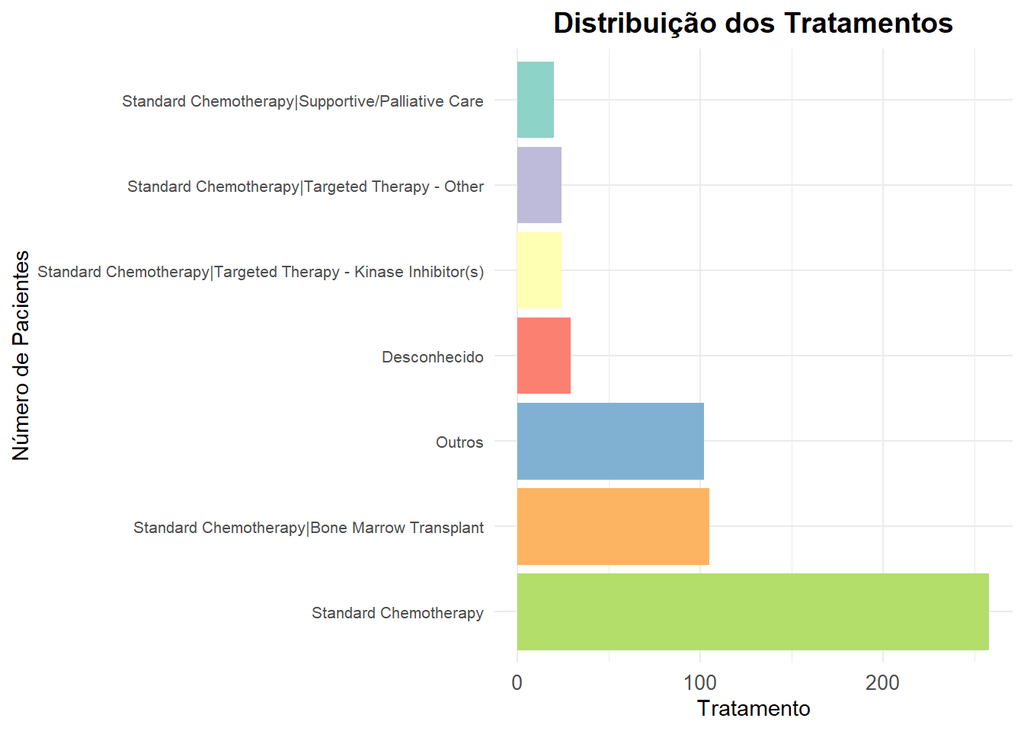

```r
dc_pacientes$TREATMENT_TYPE[dc_pacientes$TREATMENT_TYPE %in% tratamentos_raros] <- "Outros"
dc_pacientes$TREATMENT_TYPE[dc_pacientes$TREATMENT_TYPE == ""] <- "Desconhecido"
tratamento_frequencias_final <- table(dc_pacientes$TREATMENT_TYPE)
tratamento_frequencias_final_ordenado <- sort(tratamento_frequencias_final, decreasing = FALSE)

tratamento_df <- as.data.frame(tratamento_frequencias_final_ordenado)
colnames(tratamento_df) <- c("Tratamento", "Contagem")
ggplot(tratamento_df, aes(x = reorder(Tratamento, -Contagem), y = Contagem, fill = Tratamento)) +
  geom_bar(stat = "identity", show.legend = FALSE) +
  coord_flip() +
  labs(title = "Distribuição dos Tratamentos",
       x = "Número de Pacientes",
       y = "Tratamento") +
  scale_fill_brewer(palette = "Set3") +
  theme_minimal() +
  theme(axis.text.x = element_text(size = 10),
        axis.text.y = element_text(size = 8),
        plot.title = element_text(hjust = 0.5, face = "bold", size = 14))
```

## 1.6. Estado de sobrevivência

```r
table(dc_pacientes$OS_STATUS)
sum(dc_pacientes$OS_STATUS == "")
```

Os valores omissos nesta variável vão ser substituídos por estado “desconhecido”

```r
dc_pacientes$OS_STATUS[dc_pacientes$OS_STATUS == ""] <- "UNKNOWN"
table(dc_pacientes$OS_STATUS)
```

```
##
##   0:LIVING 1:DECEASED    UNKNOWN
##        215        290         57
```

```r
estado_contagens <- table(dc_pacientes$OS_STATUS)
```

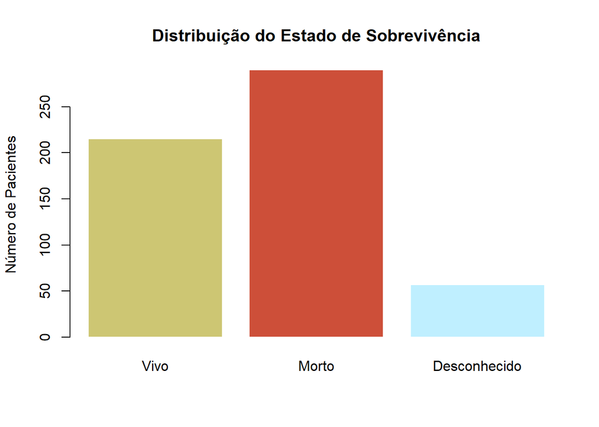

```r
barplot(estado_contagens,
        main = "Distribuição do Estado de Sobrevivência",
        ylab = "Número de Pacientes",
        col = c("khaki3", "tomato3", "lightblue1"),
        border = "white",
        names.arg = c("Vivo", "Morto", "Desconhecido"))
```

# 2. Amostras

## 2.0 Pré-análise do dataset

```r
dim(dc_amostras)
head(dc_amostras)
names(dc_amostras)
str(dc_amostras)
sum(is.na(dc_amostras))
na_por_coluna_amostras <- colSums(is.na(dc_amostras))
na_por_coluna_amostras[na_por_coluna_amostras > 0]
```

## 2.1. Classificações de risco ELN

```r
table(dc_amostras$ELN_2017)
table(dc_amostras$ELN_2017, useNA = "ifany")
```

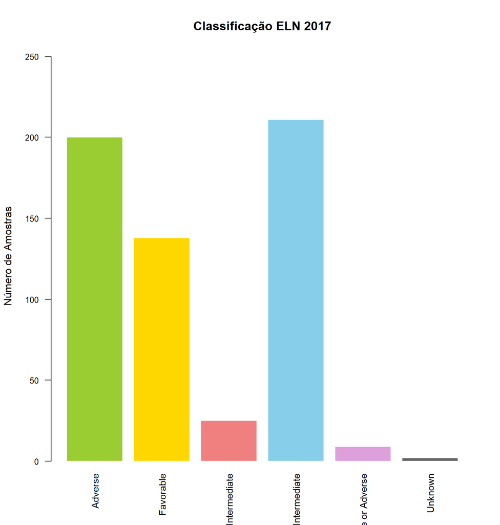

```r
eln_freq <- table(dc_amostras$ELN_2017)
cores_eln <- c("olivedrab3", "gold", "lightcoral", "skyblue", "plum", "grey40")[1:length(eln_freq)]

barplot(eln_freq,
        main = "Classificação ELN 2017",
        ylab = "Número de Amostras",
        col = cores_eln,
        border = "white",
        las = 2,
        cex.names = 0.9,
        cex.axis = 0.8,
        cex.main = 1.2,
        ylim = c(0, max(eln_freq) * 1.2))
```

## 2.2. Percentagem de blastos na medula

```r
sum(is.na(dc_amostras$BM_BLAST_PERCENTAGE))
```

### 2.2.1. Teste de normalidade (Shapiro-Wilk)

```r
shapiro_result <- shapiro.test(dc_amostras$BM_BLAST_PERCENTAGE[!is.na(dc_amostras$BM_BLAST_PERCENTAGE)])
shapiro_result
```

```
##
##  Shapiro-Wilk normality test
##
## data:  dc_amostras$BM_BLAST_PERCENTAGE[!is.na(dc_amostras$BM_BLAST_PERCENTAGE)]
## W = 0.91602, p-value = 5.45e-14
```

Como p<0.05, os dados não seguem uma distribuição normal, pelo que será utilizada a mediana.

### 2.2.2. Mediana de blastos na medula

```r
mediana_blastos <- median(dc_amostras$BM_BLAST_PERCENTAGE, na.rm = TRUE)
dc_amostras$BM_BLAST_PERCENTAGE[is.na(dc_amostras$BM_BLAST_PERCENTAGE)] <- mediana_blastos
```

### 2.2.3. Tabela sumária das estatísticas descritivas

```r
summary(dc_amostras$BM_BLAST_PERCENTAGE)
```

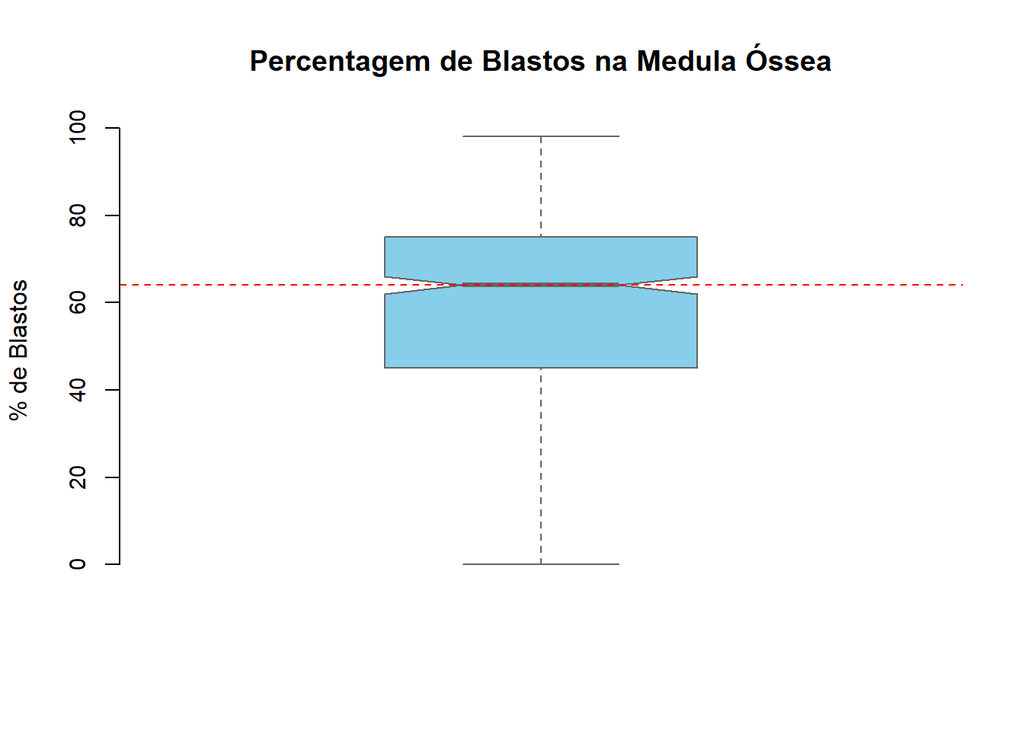

```r
boxplot(dc_amostras$BM_BLAST_PERCENTAGE,
        main = "Percentagem de Blastos na Medula Óssea",
        ylab = "% de Blastos",
        col = "skyblue",
        border = "grey40",
        notch = TRUE,
        outline = TRUE,
        frame = FALSE,
        cex.axis = 0.9,
        cex.main = 1.2)
abline(h = median(dc_amostras$BM_BLAST_PERCENTAGE, na.rm = TRUE), col = "red", lty = 2)
```

## 2.3. Percentagem de blastos no sangue periférico

```r
sum(is.na(dc_amostras$PB_BLAST_PERCENTAGE))
```

### 2.3.1. Teste de normalidade (Shapiro-Wilk)

```r
shapiro_result_pb <- shapiro.test(dc_amostras$PB_BLAST_PERCENTAGE[!is.na(dc_amostras$PB_BLAST_PERCENTAGE)])
shapiro_result_pb
```

```
##
##  Shapiro-Wilk normality test
##
## data:  dc_amostras$PB_BLAST_PERCENTAGE[!is.na(dc_amostras$PB_BLAST_PERCENTAGE)]
## W = 0.91485, p-value = 4.913e-14
```

Como p<0.05, os dados não seguem uma distribuição normal pelo que será utilizada a mediana

### 2.3.2. Mediana de blastos no sangue periférico

```r
mediana_pb_blastos <- median(dc_amostras$PB_BLAST_PERCENTAGE, na.rm = TRUE)
dc_amostras$PB_BLAST_PERCENTAGE[is.na(dc_amostras$PB_BLAST_PERCENTAGE)] <- mediana_pb_blastos
```

### 2.3.3. Tabela sumária das estatísticas descritivas

```r
summary(dc_amostras$PB_BLAST_PERCENTAGE)
```

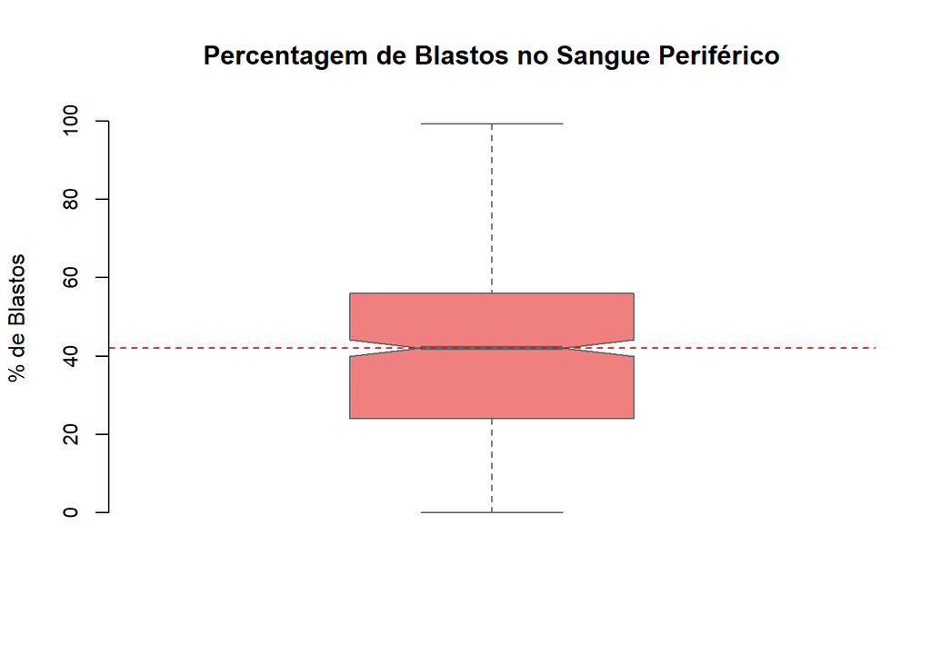

```r
boxplot(dc_amostras$PB_BLAST_PERCENTAGE,
        main = "Percentagem de Blastos no Sangue Periférico",
        ylab = "% de Blastos",
        col = "lightcoral",
        border = "grey40",
        notch = TRUE,
        outline = TRUE,
        frame = FALSE,
        cex.axis = 0.9,
        cex.main = 1.2)
abline(h = median(dc_amostras$PB_BLAST_PERCENTAGE, na.rm = TRUE), col = "red", lty = 2)
```

## 2.4. Cariótipo - ocorrências mais frequentes

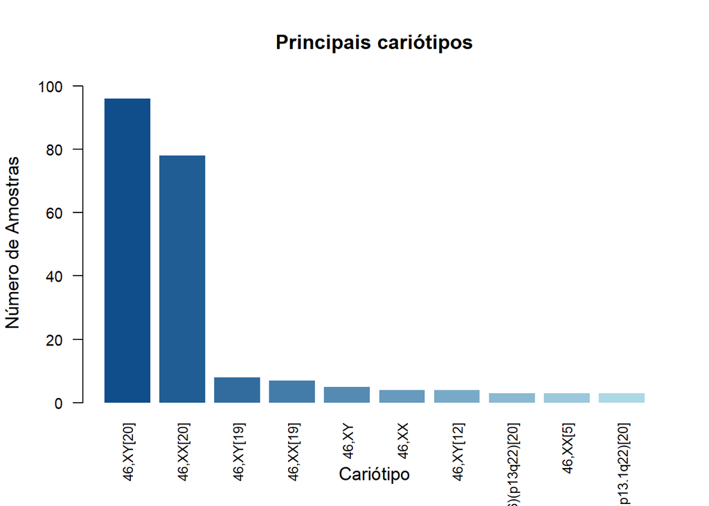

```r
karyo_clean <- dc_amostras$KARYOTYPE[dc_amostras$KARYOTYPE != ""]
karyo_freq <- sort(table(karyo_clean), decreasing = TRUE)
karyo_freq_top <- head(karyo_freq, 10)

cores_gradiente <- colorRampPalette(c("dodgerblue4", "lightblue"))(length(karyo_freq_top))
barplot(karyo_freq_top,
        main = "Principais cariótipos",
        col = cores_gradiente,
        ylab = "Número de Amostras",
        xlab = "Cariótipo",
        las = 2,
        cex.names = 0.8,
        cex.axis = 0.9,
        cex.main = 1.2,
        cex.lab = 1.1,
        border = NA,
        horiz = FALSE,
        ylim = c(0, max(karyo_freq_top) + 5),
        xpd = TRUE
)
```

## 2.5. Resposta à indução

```r
table(dc_amostras$INDUCTION_RESPONSE)
```

Reclassificação das categorias de modo a juntar todos os valores desconhecidos

```r
dc_amostras$INDUCTION_RESPONSE <- gsub("(?i)unknown|^\\s*$", "Unknown", dc_amostras$INDUCTION_RESPONSE, perl = TRUE)
```

Filtragem dos dados para excluir os valores “Unknown”

```r
induction_response_filtrados <- dc_amostras[dc_amostras$INDUCTION_RESPONSE != "Unknown", ]
table(induction_response_filtrados$INDUCTION_RESPONSE)
```

```
##
##                       Complete Response Complete Response i          Refractory
##                 100                 256                  14                 159
##             UNKNOWN
##                   6
```

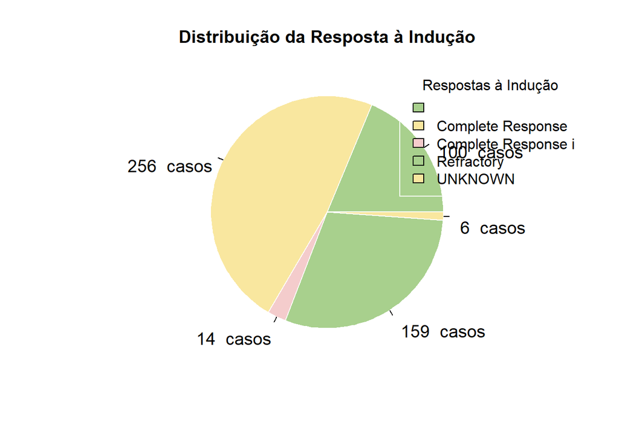

```r
response_counts <- table(induction_response_filtrados$INDUCTION_RESPONSE)
pie(response_counts,
    main = "Distribuição da Resposta à Indução",
    col = c("#A8D08D", "#F9E79F", "#F4CCCC"),  # Cores suaves
    labels = paste("\n", response_counts, " casos"),
    border = "white",
    radius = 0.9,
    cex = 1.2)
legend("topright",
       legend = names(response_counts),
       fill = c("#A8D08D", "#F9E79F", "#F4CCCC"),  # Cores harmoniosas
       title = "Respostas à Indução",
       title.col = "black",  # Cor do título
       cex = 1,  # Tamanho do texto da legenda
       box.lwd = 1,  # Espessura da borda da legenda
       box.col = "white",  # Cor da borda da legenda
       bg = "transparent")
```

## 2.6. Contagem do número de glóbulos brancos

```r
dc_amostras$WBC[dc_amostras$WBC == ""] <- NA
sum(is.na(dc_amostras$WBC))
```

```
## [1] 88
```

```r
WBC_clean <- dc_amostras$WBC[dc_amostras$WBC != "" & !is.na(dc_amostras$WBC)]
sum(is.na(WBC_clean))
```

```
## [1] 0
```

```r
WBC_clean <- as.numeric(WBC_clean)
```

Verificação de valores que não são numéricos

```r
non_numeric_values <- WBC_clean[!grepl("^[0-9.]+$", WBC_clean)]
print(non_numeric_values)
WBC_clean <- WBC_clean[grepl("^[0-9.]+$", WBC_clean)]
WBC_clean <- as.numeric(WBC_clean)
sum(is.na(WBC_clean))
summary(WBC_clean)
```

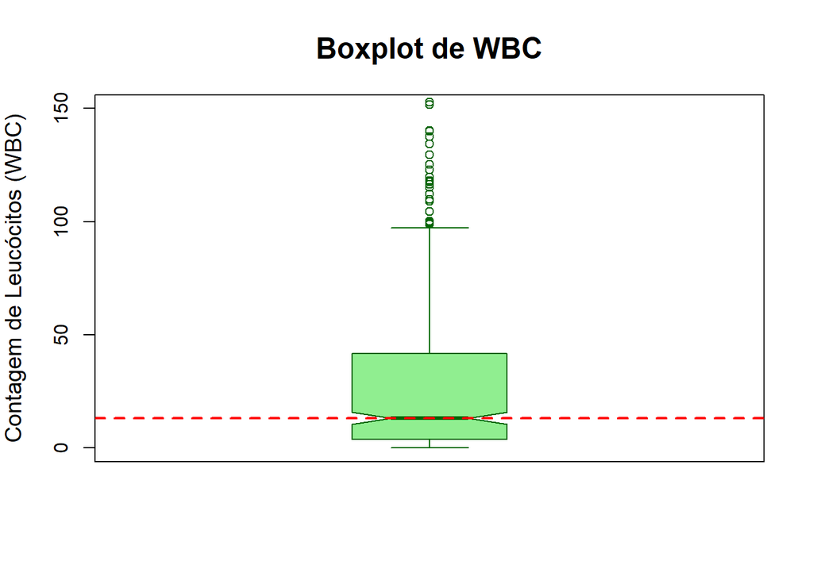

```r
boxplot(WBC_clean,
        main = "Boxplot de WBC",
        ylab = "Contagem de Leucócitos (WBC)",
        col = "lightgreen",
        border = "darkgreen",
        notch = TRUE,
        horizontal = FALSE,
        ylim = c(0, 150),
        outline = TRUE,
        whisklty = 1,
        boxwex = 0.5,
        notchcol = "darkgreen",
        main.col = "darkblue",
        cex.main = 1.5,
        cex.lab = 1.2)
abline(h = median(WBC_clean, na.rm = TRUE), col = "red", lwd = 2, lty = 2)
```

## 2.7. Estudo do efeito da resposta à indução no número de glóbulos brancos

```r
dc_amostras_limpos <- dc_amostras[!is.na(dc_amostras$WBC) & dc_amostras$WBC != "" &
                                    !is.na(dc_amostras$INDUCTION_RESPONSE) & dc_amostras$INDUCTION_RESPONSE != "", ]
str(WBC_clean)
```

```
##  num [1:497] 94 282.1 29.7 112.3 35.9 ...
```

```r
length(WBC_clean)
```

```
## [1] 497
```

```r
length(dc_amostras$INDUCTION_RESPONSE)
```

```
## [1] 585
```

```r
head(dc_amostras$WBC)
```

```
## [1] "94"    "282.1" "29.7"  "112.3" "35.9"  "58.8"
```

```r
dc_amostras$WBC_clean <- as.numeric(dc_amostras$WBC)
dc_amostras$WBC_clean[dc_amostras$WBC_clean == ""] <- NA
dados_filtrados <- dc_amostras[!is.na(dc_amostras$WBC_clean) & !is.na(dc_amostras$INDUCTION_RESPONSE), ]
length(dados_filtrados$WBC_clean)
```

```
## [1] 496
```

```r
length(dados_filtrados$INDUCTION_RESPONSE)
```

```
## [1] 496
```

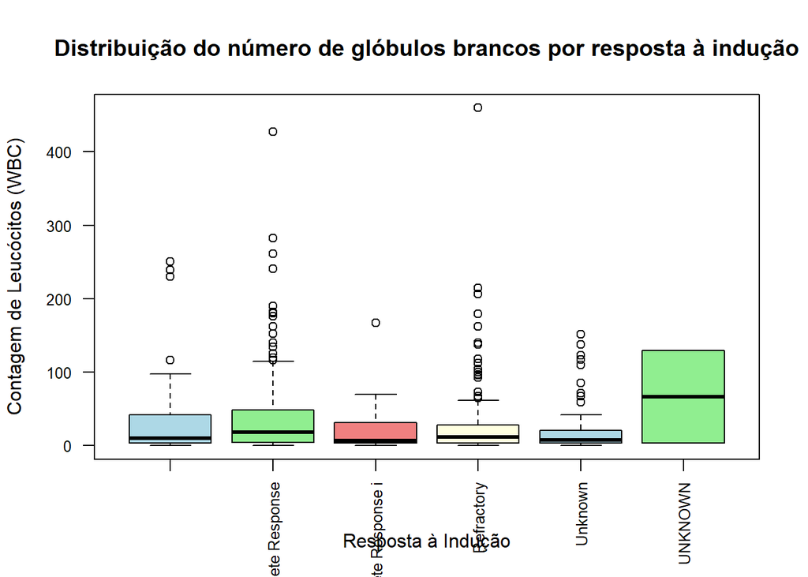

```r
boxplot(WBC_clean ~ INDUCTION_RESPONSE,
        data = dados_filtrados,
        main = "Distribuição do número de glóbulos brancos por resposta à indução",
        xlab = "Resposta à Indução",
        ylab = "Contagem de Leucócitos (WBC)",
        col = c("lightblue", "lightgreen", "lightcoral", "lightyellow"),
        border = "black",
        las = 2,
        cex.axis = 0.8)
```

### 2.7.1. Teste de Kruskal-Wallis para comparar WBC entre as categorias de resposta à indução

```r
kruskal_test_result <- kruskal.test(WBC_clean ~ INDUCTION_RESPONSE,
                                    data = dados_filtrados)
print(kruskal_test_result)
```

```
##
##  Kruskal-Wallis rank sum test
##
## data:  WBC_clean by INDUCTION_RESPONSE
## Kruskal-Wallis chi-squared = 7.402, df = 5, p-value = 0.1924
```

## 2.8. Visualização exploratória das variáveis hematológicas por grupo ELN, após normalizar os dados com z-score

### 2.8.1. Seleção e normalização

```r
variaveis_pb_norm <- dc_amostras %>%
  select(ELN_2017, PB_BASOPHILS_PERCENTAGE, PB_BLAST_PERCENTAGE, PB_EOSINOPHILS_PERCENTAGE,
         PB_IMMATURE_GRANULOCYTES_PERCENTAGE, PB_LYMPHOCYTES_PERCENTAGE,
         PB_MONOCYTES_PERCENTAGE, PB_NEUTROPHILS_PERCENTAGE, PB_NUCLEATED_RBC_PERCENTAGE) %>%
  filter(!is.na(ELN_2017)) %>%
  drop_na() %>%
  mutate(across(-ELN_2017, scale)) %>%
  pivot_longer(-ELN_2017, names_to = "Celula", values_to = "Z_score") %>%
  mutate(Celula = case_when(
    Celula == "PB_BASOPHILS_PERCENTAGE" ~ "Basófilos",
    Celula == "PB_BLAST_PERCENTAGE" ~ "Blastos",
    Celula == "PB_EOSINOPHILS_PERCENTAGE" ~ "Eosinófilos",
    Celula == "PB_IMMATURE_GRANULOCYTES_PERCENTAGE" ~ "Granulócitos Imaturos",
    Celula == "PB_LYMPHOCYTES_PERCENTAGE" ~ "Linfócitos",
    Celula == "PB_MONOCYTES_PERCENTAGE" ~ "Monócitos",
    Celula == "PB_NEUTROPHILS_PERCENTAGE" ~ "Neutrófilos",
    Celula == "PB_NUCLEATED_RBC_PERCENTAGE" ~ "Hemácias Nucleadas",
    TRUE ~ Celula
  )) %>%
  mutate(Celula = fct_reorder(Celula, Z_score, .fun = median))
```

### 2.8.2. Análise univariada comparando os valores normalizados de cada célula separadamente, entre grupos ELN, usando boxplots.

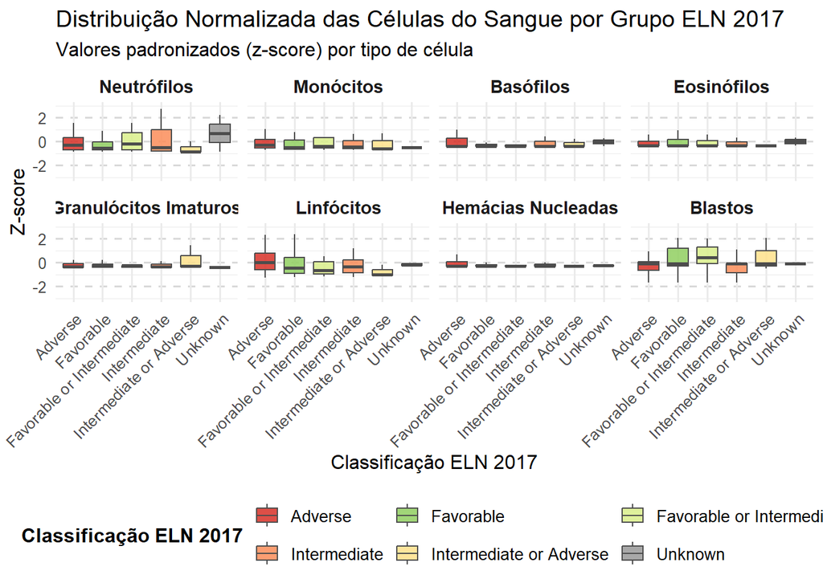

```r
paleta_eln <- c(
  "Adverse" = "#D73027",
  "Intermediate" = "#FC8D59",
  "Intermediate or Adverse" = "#FEE08B",
  "Favorable or Intermediate" = "#D9EF8B",
  "Favorable" = "#91CF60",
  "Unknown" = "#999999"
)
ggplot(variaveis_pb_norm, aes(x = ELN_2017, y = Z_score, fill = ELN_2017)) +
  geom_boxplot(outlier.shape = NA, alpha = 0.85, width = 0.7, color = "gray30") +
  facet_wrap(~ Celula, scales = "fixed", ncol = 4) +
  scale_fill_manual(values = paleta_eln, name = "Classificação ELN 2017") +
  coord_cartesian(ylim = c(-3, 3)) +
  theme_minimal(base_size = 12) +
  labs(
    title = "Distribuição Normalizada das Células do Sangue por Grupo ELN 2017",
    subtitle = "Valores padronizados (z-score) por tipo de célula",
    x = "Classificação ELN 2017", y = "Z-score"
  ) +
  theme(
    axis.text.x = element_text(angle = 45, hjust = 1),
    panel.grid.major.y = element_line(color = "gray85", linetype = "dashed"),
    strip.text = element_text(face = "bold", size = 11),
    legend.position = "bottom",
    legend.title = element_text(face = "bold"),
    legend.text = element_text(size = 10)
  ) +
  guides(fill = guide_legend(nrow = 2, byrow = TRUE))
```

## 2.9. Análise de Componentes Principais (PCA) para caracterizar as Células Sanguíneas no contexto da Classificação ELN 2017

### 2.9.1. Seleção e normalização

```r
dados_celulas_pb_scaled <- dc_amostras %>%
  select(ELN_2017, PB_BASOPHILS_PERCENTAGE, PB_BLAST_PERCENTAGE, PB_EOSINOPHILS_PERCENTAGE,
         PB_IMMATURE_GRANULOCYTES_PERCENTAGE, PB_LYMPHOCYTES_PERCENTAGE,
         PB_MONOCYTES_PERCENTAGE, PB_NEUTROPHILS_PERCENTAGE, PB_NUCLEATED_RBC_PERCENTAGE) %>%
  filter(!is.na(ELN_2017)) %>%
  drop_na()

matriz_numeric <- dados_celulas_pb_scaled %>%
  select(-ELN_2017) %>%
  scale()
```

### 2.9.1. Resultado do PCA

```r
pca_result <- prcomp(matriz_numeric, center = TRUE, scale. = TRUE)
pca_result
```

```
## Standard deviations (1, .., p=8):
## [1] 1.2848067 1.1928975 1.0431399 1.0096878 0.9373447 0.9254560 0.8812223
## [8] 0.5540942
##
## Rotation (n x k) = (8 x 8):
##                                             PC1         PC2         PC3
## PB_BASOPHILS_PERCENTAGE             -0.16420195  0.45983826 -0.17216269
## PB_BLAST_PERCENTAGE                  0.64959428  0.02800424 -0.33795557
## PB_EOSINOPHILS_PERCENTAGE           -0.20075948  0.44995218  0.07260989
## PB_IMMATURE_GRANULOCYTES_PERCENTAGE  0.09390529  0.51292633  0.05820582
## PB_LYMPHOCYTES_PERCENTAGE           -0.45266884 -0.45708899 -0.11986200
## PB_MONOCYTES_PERCENTAGE              0.20834705  0.05364737  0.83346341
## PB_NEUTROPHILS_PERCENTAGE           -0.50254369  0.21975466  0.07851128
## PB_NUCLEATED_RBC_PERCENTAGE          0.03278259 -0.24922610  0.36372209
##                                             PC4         PC5         PC6
## PB_BASOPHILS_PERCENTAGE             -0.31332059  0.23072130 -0.63303186
## PB_BLAST_PERCENTAGE                 -0.03414626 -0.09402584  0.16500144
## PB_EOSINOPHILS_PERCENTAGE           -0.02189161  0.38560743  0.71125228
## PB_IMMATURE_GRANULOCYTES_PERCENTAGE -0.43037131 -0.10817275  0.05653638
## PB_LYMPHOCYTES_PERCENTAGE           -0.27262084  0.40038256  0.04820649
## PB_MONOCYTES_PERCENTAGE              0.20517864  0.25959196 -0.19179470
## PB_NEUTROPHILS_PERCENTAGE            0.26989423 -0.64775063  0.03344925
## PB_NUCLEATED_RBC_PERCENTAGE         -0.72505326 -0.36091181  0.15080151
##                                             PC7          PC8
## PB_BASOPHILS_PERCENTAGE              0.40515292  0.125164565
## PB_BLAST_PERCENTAGE                  0.17896482  0.627509653
## PB_EOSINOPHILS_PERCENTAGE            0.31121644  0.007658301
## PB_IMMATURE_GRANULOCYTES_PERCENTAGE -0.72157559  0.062545635
## PB_LYMPHOCYTES_PERCENTAGE           -0.24156398  0.525821582
## PB_MONOCYTES_PERCENTAGE             -0.01475712  0.335504060
## PB_NEUTROPHILS_PERCENTAGE            0.07407065  0.440414155
## PB_NUCLEATED_RBC_PERCENTAGE          0.34962595 -0.059824100
```

```r
pca_data <- as.data.frame(pca_result$x)
pca_data$ELN_2017 <- dados_celulas_pb_scaled$ELN_2017

pca_data <- as.data.frame(pca_result$x)
pca_data$ELN_2017 <- dc_amostras$ELN_2017[!is.na(dc_amostras$PB_BASOPHILS_PERCENTAGE) &
                                            !is.na(dc_amostras$PB_BLAST_PERCENTAGE) &
                                            !is.na(dc_amostras$PB_EOSINOPHILS_PERCENTAGE) &
                                            !is.na(dc_amostras$PB_IMMATURE_GRANULOCYTES_PERCENTAGE) &
                                            !is.na(dc_amostras$PB_LYMPHOCYTES_PERCENTAGE) &
                                            !is.na(dc_amostras$PB_MONOCYTES_PERCENTAGE) &
                                            !is.na(dc_amostras$PB_NEUTROPHILS_PERCENTAGE) &
                                            !is.na(dc_amostras$PB_NUCLEATED_RBC_PERCENTAGE)]
```

### 2.9.2. Gráfico de dispersão entre PC1 e PC2

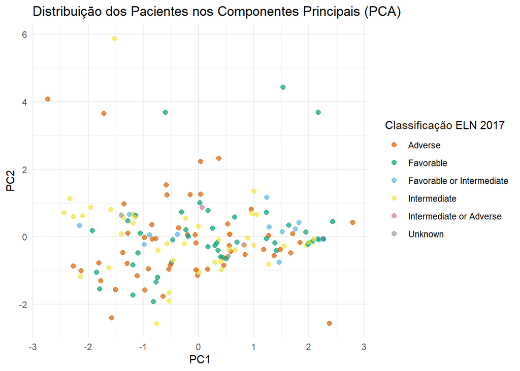

```r
ggplot(pca_data, aes(x = PC1, y = PC2, color = ELN_2017)) +
  geom_point(alpha = 0.7, size = 2) +
  scale_color_manual(values = c("Adverse" = "#D55E00", "Favorable" = "#009E73",
                                "Favorable or Intermediate" = "#56B4E9",
                                "Intermediate" = "#F0E442",
                                "Intermediate or Adverse" = "#CC79A7",
                                "Unknown" = "#999999")) +
  labs(title = "Distribuição dos Pacientes nos Componentes Principais (PCA)",
       x = "PC1", y = "PC2", color = "Classificação ELN 2017") +
  theme_minimal() +
  theme(legend.position = "right")
```

### 2.9.3. Gráfico de dispersão entre PC1 e PC3

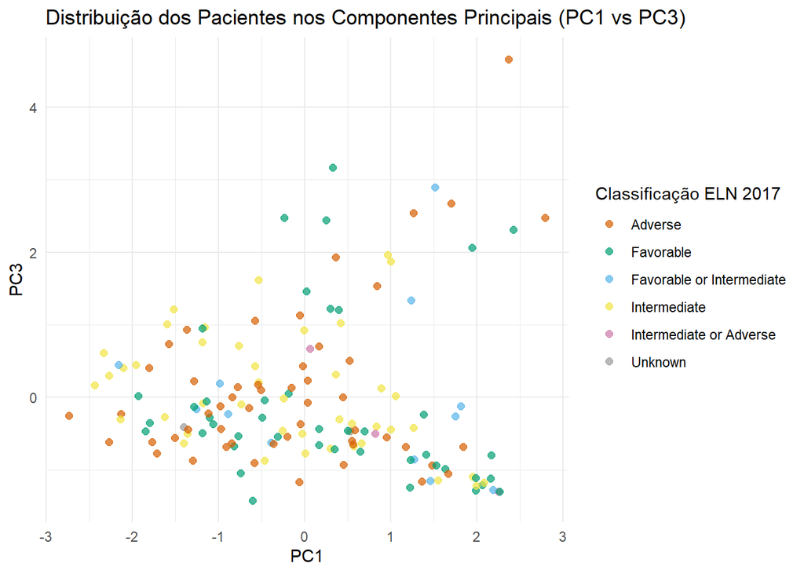

```r
ggplot(pca_data, aes(x = PC1, y = PC3, color = ELN_2017)) +
  geom_point(alpha = 0.7, size = 2) +
  scale_color_manual(values = c("Adverse" = "#D55E00", "Favorable" = "#009E73",
                                "Favorable or Intermediate" = "#56B4E9",
                                "Intermediate" = "#F0E442",
                                "Intermediate or Adverse" = "#CC79A7",
                                "Unknown" = "#999999")) +
  labs(title = "Distribuição dos Pacientes nos Componentes Principais (PC1 vs PC3)",
       x = "PC1", y = "PC3", color = "Classificação ELN 2017") +
  theme_minimal() +
  theme(legend.position = "right")
```

### 2.9.4. Gráfico de barras para a proporção da variância explicada

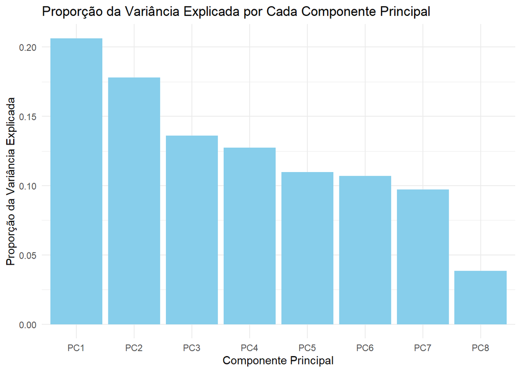

```r
variancia <- summary(pca_result)$importance[2, ]
variancia_df <- data.frame(Component = paste0("PC", 1:length(variancia)), Variance_Proportion = variancia)

ggplot(variancia_df, aes(x = Component, y = Variance_Proportion)) +
  geom_bar(stat = "identity", fill = "skyblue") +
  labs(title = "Proporção da Variância Explicada por Cada Componente Principal",
       x = "Componente Principal", y = "Proporção da Variância Explicada") +
  theme_minimal()
```